# Sample Analysis

Author

Prabin Roka

# 1 Introduction

### 1.0.1 Decoding Tipping Patterns

Tipping is more than a casual act of generosity — it’s a behavioral response woven into social expectations, economic status, and service experiences. In this project, we explore these patterns using the **TIPS dataset**, which captures real-world tipping decisions recorded by a single server at a restaurant over several months.

Our analysis uses a blend of exploratory data techniques and predictive modeling to better understand what drives tipping. Specifically, we aim to answer three central questions:

Our goal is to answer the following questions:

1. **What factors most strongly influence how people tip?**
2. **Can we accurately predict tip amounts or categories using statistical models?**
3. **What insights can help restaurants improve service and revenue through tipping behavior?**

Initial findings suggest that variables like `Bill` and `PartySize` are correlated with tipping, but there may be deeper, unmeasured influences at play — such as customer satisfaction or service quality — that deserve attention. By building and evaluating predictive models, we test how well we can capture the complexity of tipping behavior and offer practical takeaways for stakeholders in the hospitality industry.

# 2 Understanding the Data

### 2.0.1 Data Overview

We begin by loading the `TIPS` dataset from the `regclass` package. This dataset contains 244 observations across 8 variables, including:

- `bill`: Total bill before the tip
- `tip`: Tip amount
- `gender`: Server gender
- `smoker`: Whether the party included smokers
- `weekday`: Day of the week
- `time`: Lunch or dinner service
- `party_size`: Number of diners

# 3 Exploratory Data Analysis

With the dataset cleaned and loaded, we begin by examining the shape and structure of the data. The `TIPS` dataset contains 244 observations and 8 variables, including numerical features like `Bill`, `Tip`, and `TipPercentage`, and categorical ones like `Gender`, `Smoker`, `Weekday`, and `Time`.

```r
library(tidyverse)
library(regclass)

data("TIPS")
str(TIPS)
```

```
'data.frame':   244 obs. of  8 variables:
 $ TipPercentage: num  5.94 16.1 16.7 14 14.7 18.6 22.8 11.6 13 21.9 ...
 $ Bill         : num  17 10.3 21 23.7 24.6 ...
 $ Tip          : num  1.01 1.66 3.5 3.31 3.61 4.71 2 3.12 1.96 3.23 ...
 $ Gender       : Factor w/ 2 levels "Female","Male": 1 2 2 2 1 2 2 2 2 2 ...
 $ Smoker       : Factor w/ 2 levels "No","Yes": 1 1 1 1 1 1 1 1 1 1 ...
 $ Weekday      : Factor w/ 4 levels "Friday","Saturday",..: 3 3 3 3 3 3 3 3 3 3 ...
 $ Time         : Factor w/ 2 levels "Day","Night": 2 2 2 2 2 2 2 2 2 2 ...
 $ PartySize    : int  2 3 3 2 4 4 2 4 2 2 ...
```

```r
summary(TIPS)
```

```
 TipPercentage        Bill            Tip            Gender    Smoker
 Min.   : 3.56   Min.   : 3.07   Min.   : 1.000   Female: 87   No :151
 1st Qu.:12.88   1st Qu.:13.35   1st Qu.: 2.000   Male  :157   Yes: 93
 Median :15.45   Median :17.80   Median : 2.900
 Mean   :16.08   Mean   :19.79   Mean   : 2.998
 3rd Qu.:19.12   3rd Qu.:24.13   3rd Qu.: 3.562
 Max.   :71.00   Max.   :50.81   Max.   :10.000
     Weekday      Time       PartySize
 Friday  :19   Day  : 68   Min.   :1.00
 Saturday:87   Night:176   1st Qu.:2.00
 Sunday  :76               Median :2.00
 Thursday:62               Mean   :2.57
                           3rd Qu.:3.00
                           Max.   :6.00
```

### 3.0.1 Visualizing Key Distributions

To uncover patterns and outliers, we now turn to visualizations of individual variables. Our focus is on understanding the spread of tips and bills, along with groupings based on demographic or contextual factors.

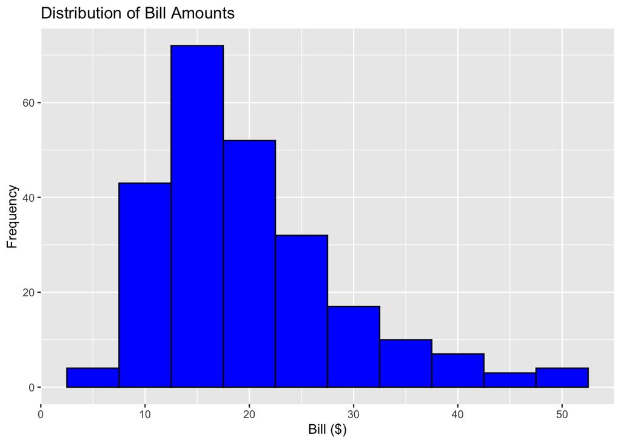

```r
library(ggplot2)

# Bill distribution
ggplot(TIPS, aes(x = Bill)) +
  geom_histogram(binwidth = 5, fill = "blue", color = "black") +
  labs(title = "Distribution of Bill Amounts", x = "Bill ($)", y = "Frequency")
```

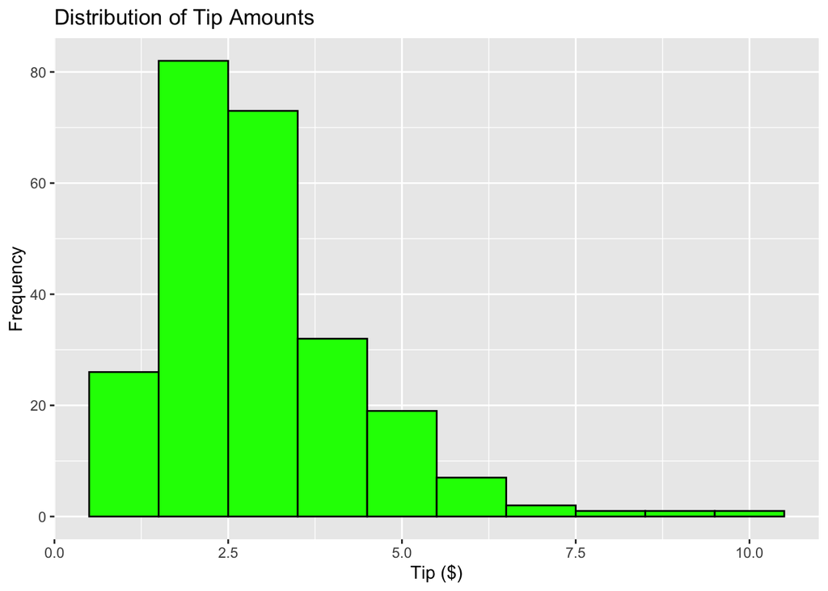

```r
# Tip distribution
ggplot(TIPS, aes(x = Tip)) +
  geom_histogram(binwidth = 1, fill = "green", color = "black") +
  labs(title = "Distribution of Tip Amounts", x = "Tip ($)", y = "Frequency")
```

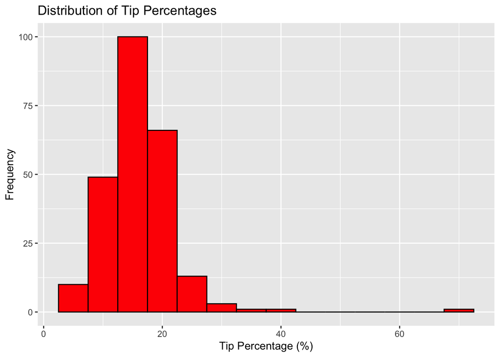

```r
# Tip percentage distribution
ggplot(TIPS, aes(x = TipPercentage)) +
  geom_histogram(binwidth = 5, fill = "red", color = "black") +
  labs(title = "Distribution of Tip Percentages", x = "Tip Percentage (%)", y = "Frequency")
```

These histograms reveal strong right-skewness in both `Bill`and `Tip` distributions, as expected in a restaurant setting. Most bills fall between $10 and $40, while tips typically range from $1 to $5. Tip percentages cluster between 10% and 20%, though a few outliers do tip more generously.

We also explore the categorical variables:

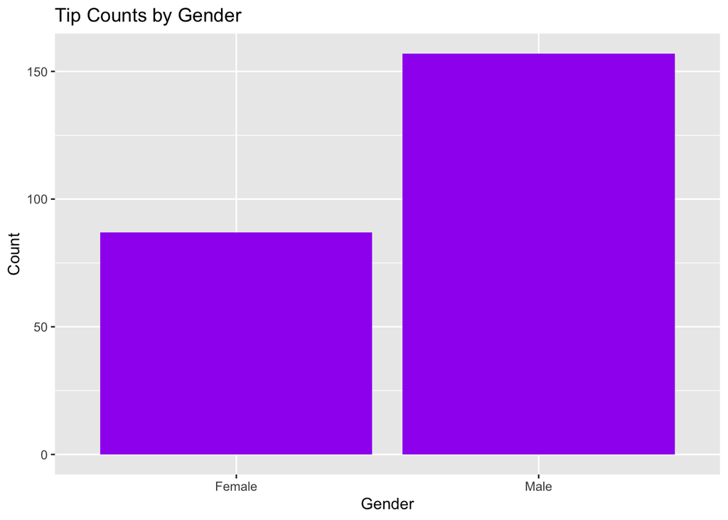

```r
# Gender distribution
ggplot(TIPS, aes(x = Gender)) +
  geom_bar(fill = "purple") +
  labs(title = "Tip Counts by Gender", x = "Gender", y = "Count")
```

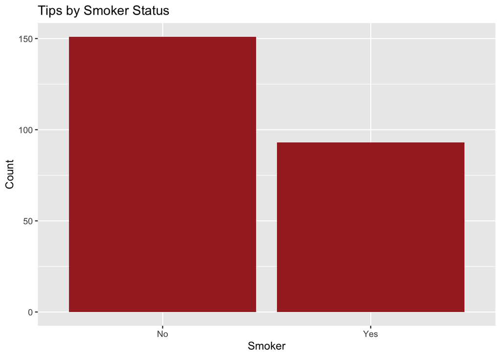

```r
# Smoker status
ggplot(TIPS, aes(x = Smoker)) +
  geom_bar(fill = "brown") +
  labs(title = "Tips by Smoker Status", x = "Smoker", y = "Count")
```

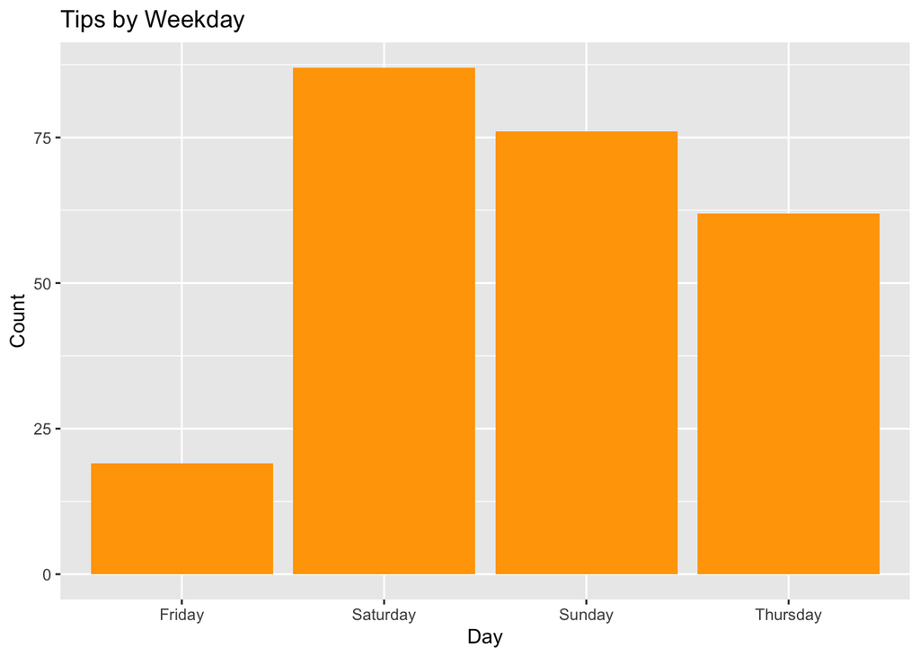

```r
# Day of week
ggplot(TIPS, aes(x = Weekday)) +
  geom_bar(fill = "orange") +
  labs(title = "Tips by Weekday", x = "Day", y = "Count")
```

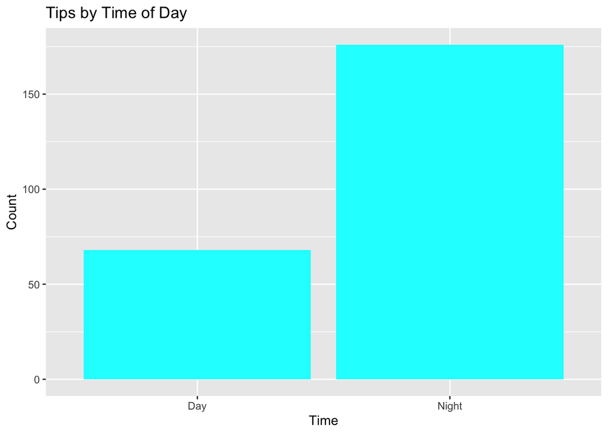

```r
# Time of day
ggplot(TIPS, aes(x = Time)) +
  geom_bar(fill = "cyan") +
  labs(title = "Tips by Time of Day", x = "Time", y = "Count")
```

Most tipping occurs during the night and on weekends — notably Saturdays and Sundays — which likely reflects restaurant foot traffic patterns. Interestingly, more tips are recorded for male servers and non-smokers.

## 3.1 Exploring Relationships Between Variables

Beyond univariate summaries, it’s important to investigate how variables relate to each other — especially`TipPercentage`, our primary outcome of interest.

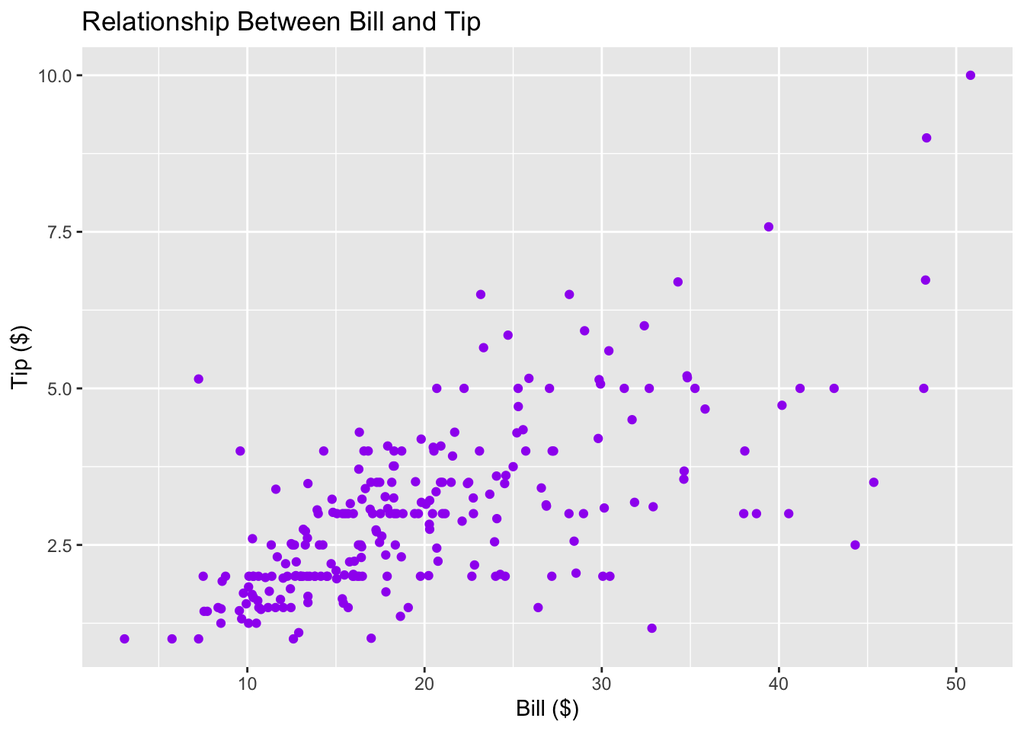

```r
# Bill vs Tip
ggplot(TIPS, aes(x = Bill, y = Tip)) +
  geom_point(color = "purple") +
  labs(title = "Relationship Between Bill and Tip", x = "Bill ($)", y = "Tip ($)")
```

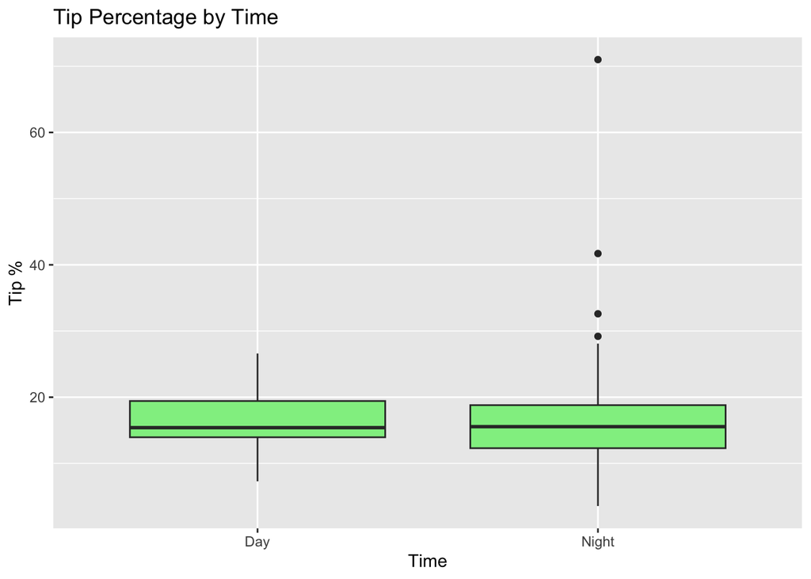

```r
# Tip percentage by time of day
ggplot(TIPS, aes(x = Time, y = TipPercentage)) +
  geom_boxplot(fill = "lightgreen") +
  labs(title = "Tip Percentage by Time", x = "Time", y = "Tip %")
```

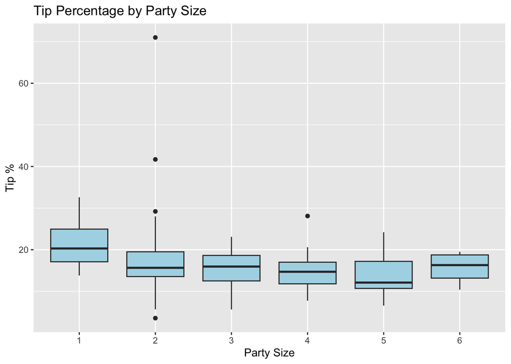

```r
# Tip percentage by party size
ggplot(TIPS, aes(x = as.factor(PartySize), y = TipPercentage)) +
  geom_boxplot(fill = "lightblue") +
  labs(title = "Tip Percentage by Party Size", x = "Party Size", y = "Tip %")
```

# 4 Additional Feature Engineering and Data Preparation

Before diving into predictive modeling, we explored additional transformations to improve accuracy and potentially capture deeper patterns in tipping behavior. This exploratory phase involved several key steps:

### 4.0.1 Interaction Variable

We introduced a new feature, `party_day`, representing an interaction between `party_size` and the numeric representation of `weekday`. The intuition was that larger groups might tip differently on certain days — for example, a group of five on a weekend may behave differently than on a weekday.

### 4.0.2 Encoding

Categorical variables such as `gender`, `smoker`, `weekday`, and `time` were encoded into numeric format to make them compatible with algorithms that require numerical input.

### 4.0.3 Missing Data

A check for missing values confirmed that the dataset was clean — no imputation was necessary.

```r
TIPS <- tips |>
  mutate(party_day = party_size * as.numeric(weekday))

TIPS_encoded <- TIPS |>
  mutate(across(c(gender, smoker, weekday, time), as.factor)) |>
  mutate_if(is.factor, as.numeric)

sum(is.na(TIPS_encoded))  # Confirm no missing values
```

```
[1] 0
```

# 5 Data Preparation for Modeling

We then split the data into training (70%) and testing (30%) subsets to evaluate model performance on unseen observations.

```r
set.seed(427)
split <- initial_split(TIPS_encoded, prop = 0.7)
train_data <- training(split)
test_data <- testing(split)
```

# 6 Predictive Modeling

We used two different modeling approaches to examine tipping behavior:

## 6.1 **Linear Regression: Predicting Tip Percentage**

To start, we trained a linear regression model using `Bill`, `PartySize`, and encoded versions of `Gender`, `Smoker`, and `Time`as predictors for `TipPercentage`.

```r
lm_model <- linear_reg() |>
  set_engine("lm") |>
  set_mode("regression")

lm_fit <- lm_model |>
  fit(tip_percentage ~ bill + party_size + gender + smoker + time + party_day, data = train_data)

summary(lm_fit$fit)
```

```
Call:
stats::lm(formula = tip_percentage ~ bill + party_size + gender +
    smoker + time + party_day, data = data)

Residuals:
    Min      1Q  Median      3Q     Max
-10.799  -3.708  -0.801   1.950  50.519

Coefficients:
            Estimate Std. Error t value Pr(>|t|)
(Intercept) 17.91479    3.32008   5.396 2.37e-07 ***
bill        -0.27601    0.06922  -3.987 0.000101 ***
party_size  -0.28541    1.09084  -0.262 0.793925
gender      -0.35398    1.04698  -0.338 0.735727
smoker       1.40705    1.04902   1.341 0.181690
time         0.74311    1.38132   0.538 0.591328
party_day    0.25761    0.26345   0.978 0.329607
---
Signif. codes:  0 '***' 0.001 '**' 0.01 '*' 0.05 '.' 0.1 ' ' 1

Residual standard error: 6.265 on 163 degrees of freedom
Multiple R-squared:  0.1333,    Adjusted R-squared:  0.1014
F-statistic: 4.178 on 6 and 163 DF,  p-value: 0.0006181
```

### 6.1.1 Interpretation:

The linear regression model yielded a low R² of approximately 13.4%, suggesting it explains only a small fraction of the variability in tip percentages. The root mean squared error (RMSE) was about 6.27, indicating substantial prediction error.

Other variables — including `PartySize`, `Gender`, `Smoker`, PartyDay and `Time` — were not statistically significant in this model. Their weak influence and high p-values suggest they don’t offer meaningful predictive value in this context.

## 6.2 K-Nearest Neighbors: Predicting Tip Categories

To explore tipping behavior in a more categorical way, we transformed the numeric `Tip` values into three groups:

- **Low**: Tip < $2
- **Medium**: Tip between $2 and $4
- **High**: Tip ≥ $4

We then applied a **K-Nearest Neighbors (KNN)** classification model with `k = 5` to predict the `TipCategory` using predictors such as `Bill`, `PartySize`, `Gender`, `Smoker`, `Weekday`, and `Time`.

### 6.2.1 Data Preparation

```r
train_data_class <- train_data |>
  mutate(tip_category = case_when(
    tip < 2 ~ "Low",
    tip >= 2 & tip < 4 ~ "Medium",
    tip >= 4 ~ "High"
  ) |> factor())

test_data_class <- test_data |>
  mutate(tip_category = case_when(
    tip < 2 ~ "Low",
    tip >= 2 & tip < 4 ~ "Medium",
    tip >= 4 ~ "High"
  ) |> factor())
```

We built a modeling recipe to handle dummy encoding for categorical predictors and normalization of numeric variables, which is essential for KNN to perform properly.

```r
library(recipes)
library(parsnip)
library(workflows)

tip_class_recipe <- recipe(tip_category ~ bill + party_size + gender + smoker + weekday + time, data = train_data_class) |>
  step_dummy(all_nominal_predictors()) |>
  step_normalize(all_predictors())

knn_model <- nearest_neighbor(neighbors = 5) |>
  set_engine("kknn") |>
  set_mode("classification")

knn_workflow <- workflow() |>
  add_recipe(tip_class_recipe) |>
  add_model(knn_model)

knn_fit <- knn_workflow |>
  fit(train_data_class)
```

### 6.2.2 Predictions and Evaluation

Using the trained KNN model, we predicted the `TipCategory` for the test dataset. Below are the performance metrics obtained from the predictions:

```r
knn_predictions <- predict(knn_fit, new_data = test_data_class) |>
  bind_cols(test_data_class)

library(yardstick)

knn_metrics <- metric_set(accuracy, precision, recall, f_meas)(
  knn_predictions, truth = tip_category, estimate = .pred_class
)

print(knn_metrics)
```

```
# A tibble: 4 × 3
  .metric   .estimator .estimate
  <chr>     <chr>          <dbl>
1 accuracy  multiclass     0.622
2 precision macro          0.545
3 recall    macro          0.586
4 f_meas    macro          0.545
```

These metrics reflect macro-averaged scores across the three classes: `Low`, `Medium`, and `High`.

## 6.3 Interpretation

- **Precision** of 54.5% indicates that when the model predicts a category, it’s right about half the time.
- **Recall** of 58.5% means it captures a bit more than half of the actual categories present in the data.
- **F1 Score**, which balances both precision and recall, reinforces the modest predictive power of the model.

The model appears to perform best on the **Medium** tip category — likely because it represents the bulk of the data, making it easier to classify. In contrast, **Low** and **High** tip classes are less predictable, possibly because they’re driven by factors not captured in the dataset, such as service quality, server friendliness, or customer mood.

Ultimately, the KNN model offers a decent, though limited, glimpse into tip classification and would likely benefit from more granular data or the inclusion of external features like server ratings or time spent at the table.

# 7 Conclusion and Recommendations

## 7.2 Recommendations for Practice and Future Analysis

- **Collect richer data**: Variables such as customer satisfaction, duration of service, or server ID could significantly improve prediction models.
- **Model fine-tuning**: Future work could explore more sophisticated models (e.g., random forests or support vector machines) and conduct hyperparameter tuning for improved accuracy.
- **Focus on experience**: Since service quality likely plays a major hidden role in tipping, efforts to train, retain, and reward staff performance may have the biggest impact — even more than customer bill size or party demographics.
- **Don’t over-rely on bill size**: While it’s correlated with tipping, it’s not always predictive of generosity. Focus on customer satisfaction instead.

Tipping is a behavior wrapped in culture, psychology, and individual judgment. This project reveals that while we can model some of it, the most meaningful factors may lie outside what any dataset can fully capture.

## 7.3 Note

Some parts of this report — including formatting, visuals, and debugging — were done with the help of AI tools. Everything that was generated using AI was fully reviewed, understood, and interpreted by me before being included in the final report.